# Aplicaciones de sistemas de información geográfica

2023-09-27

Muchas aplicaciones de sistemas de información geográfica en macroecología requieren de análisis estadísticos. La plataforma por excelencia para realizarlos es **R**, aún más con las excelentes capacidades de **R** por sí solo como SIG. En este tutorial veremos cómo:

1. Importar datos geográficos: puntos, líneas, polígonos y raster
2. Transformar entre tipos de datos
3. Reproyectar datos
4. Hacer un análisis de regresión con los datos geográficos
   - Interpretar el análisis

## Importar datos

Al igual que en el tutorial de GBIF utilizaremos el paquete `terra` para importar y manipular todos los datos geográficos. De los datos usados, los puntos, líneas y polígonos pueden ser manejados como vectoriales. Las extensiones de archivo más comunes para estos son `gpkg` y `shp`. Los puntos, por carecer de más características geométricas son más sencillos y se les suele también encontrar como `csv`.

Comenzaremos cargando el paquete `terra`, y la capa vectorial de Yucatán, Campeche y Quitana Roo:

```r
library(terra); library(tidyr)
py <- vect("Datos/Peninsula.gpkg")
```

el objeto `py` es el que contiene la capa, y podemos ver su tabla de atributos imprimiendo el objeto como un `data.frame` (usando la sintaxis de `tidyr`):

```r
py |> as.data.frame()
```

```
##      GID_1 GID_0 COUNTRY       NAME_1 VARNAME_1 NL_NAME_1 TYPE_1 ENGTYPE_1 CC_1
## 1  MEX.4_1   MEX  México     Campeche        NA        NA Estado     State   NA
## 2 MEX.23_1   MEX  México Quintana Roo        NA        NA Estado     State   NA
## 3 MEX.31_1   MEX  México      Yucatán        NA        NA Estado     State   NA
##   HASC_1  ISO_1
## 1  MX.CM MX-CAM
## 2  MX.QR MX-ROO
## 3  MX.YU     NA
```

Para ver la proyección geográfica de la capa:

```r
crs(py, describe = T)
```

```
##     name authority code  area             extent
## 1 WGS 84      EPSG 4326 World -180, 180, 90, -90
```

Para importar capas de líneas se usa la misma función `vect`. Para importar datos de puntos, podemos usar `read.csv` ó `vect` dependiendo de la extensión del archivo. Si los datos los obtuvimos de GBIF serán `csv`. Si los datos de GBIF lo hemos limpiado con anterioridad, es posible que los hayamos guarado como `gpkg` ó `shp`:

```r
cd.csv <- read.csv("Datos/Cachryx.csv")
cd.gpkg <- vect("Datos/Cachryx.csv")
```

Al verificar la proyección de estos datos, podemos ver que está vacía:

```r
crs(cd.gpkg, describe = T)
```

```
##      name authority code area         extent
## 1 unknown      <NA> <NA> <NA> NA, NA, NA, NA
```

y podemos expecificarla utilizando la proyección de la capa vectorial de la península, si de antemano sabemos que tienen la misma:

```r
crs(cd.gpkg) <- crs(py)
crs(cd.gpkg, describe = T)
```

```
##     name authority code  area             extent
## 1 WGS 84      EPSG 4326 World -180, 180, 90, -90
```

Para especificar la proyección de puntos importados desde un `csv`, necesitamos transformarlo a un objeto reconocible por terra:

```r
cd.v <- vect(cd.csv)
crs(cd.v) <- crs(py)
crs(cd.v, describe = T)
```

```
##     name authority code  area             extent
## 1 WGS 84      EPSG 4326 World -180, 180, 90, -90
```

## Reproyectar datos

El sistema de coordenadas más común es WGS84, que en la lista EPSG tiene el número 4326. WGS84 tiene coordenadas polares, medidas en grados, lo que quiere decir que son coordenadas geográficas y se deben utilizar para ubicar objetos en la superficie terrestre. Cuando queremos medir distancias ó áreas, necesitamos coordenadas proyectadas, que representen la superficie de la tierra con la menor cantidad de distorsiones en una superficie plana como la pantalla de la computadora. Los sistemas de coordenadas están diseñados para regiones específicas, y las podemos encontrar utilizando el nombre de la región y los códigos EPSG. En QGIS podemos buscar los sistemas de coordenadas haciendo click en el botón “EPSG” de al esquina inferior derecha:

[figure not shown]

El sistema por defecto es precisamente EPSG, con cobertura global:

[figure not shown]

En esta ventana podemos buscar sistemas de coordenadas propias de una región geográfica. Para México por ejemplo, está ITRF2008, EPSG:6363.

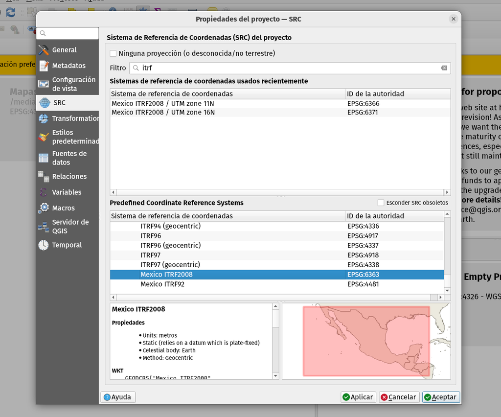

Además, hay proyecciones para zonas específicas, como la zona 16N de ITRF2008 (EPSG:6371):

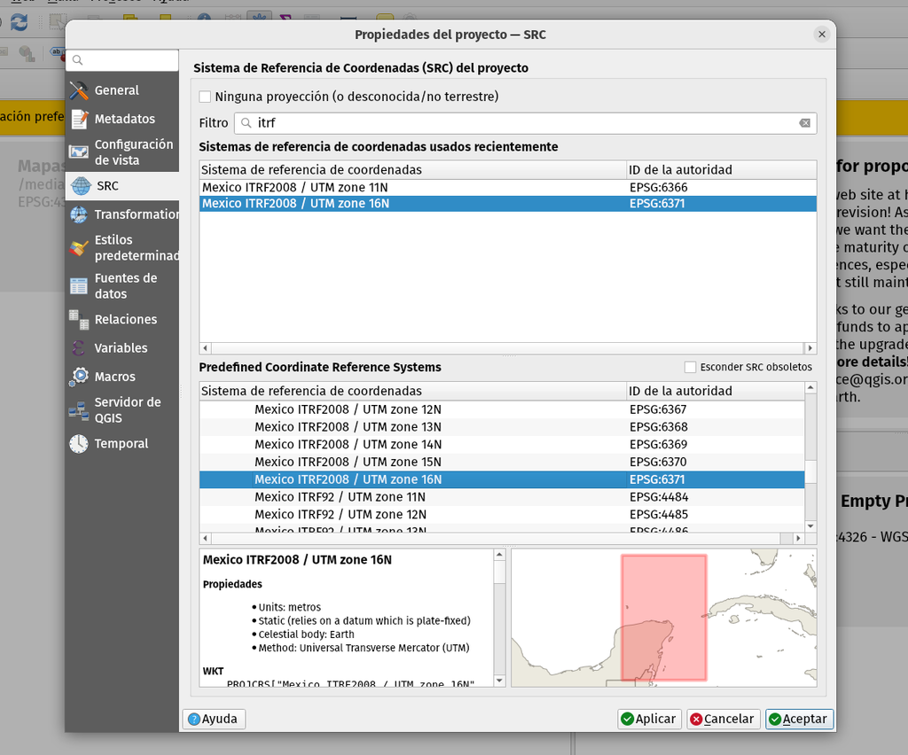

Una vez identificadas las proyecciones adecuadas para nuestros datos, haremos el cambio de proyección a ITRF2008-16N (EPSG:6371):

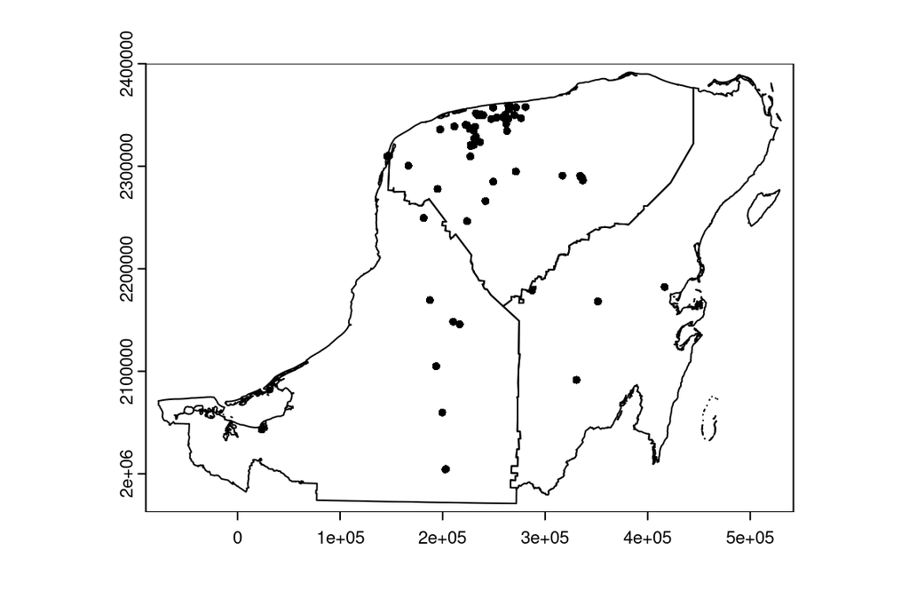

```r
cd.v.it <- project(cd.v, "EPSG:6371")
py.it <- project(py, "EPSG:6371")
plot(py.it); points(cd.v.it)
```

El sistema de referencia de las coordenadas es importante cuando necesitamos calcular áreas ó distancias. En macroecología y biogeografía entonces, es de muy alta importancia poder estimar adecuadamente las áreas.

## Análisis de regresión con datos geográficos

Importaremos aquí las distribuciones de mamíferos de PHYLACINE, para hacer un análisis de las variables ambientales a que está asociada la riqueza. Comenzaremos importando las distribuciones con la función `rast` de `terra`. A esta función le podemos dar uno ó cientos de nombres de archivos para generar una capa raster con múltiples bandas. La lista de archivos podemos crearla con `list.files`:

```r
f <- list.files("../Current/Current/", pattern = ".tif", full.names = T)
length(f)
```

```
## [1] 5831
```

Como podemos ver, hay 5831 archivos raster con extensión `tif`, de ahí que a `list.files` primero le indicamos en qué carpeta buscar (`../Current/Current/`) y después la cadena de texto que debe identificar en los archivos, que es la extensión. Una vez generada la lista de archivos, la importamos con `rast`:

```r
r <- rast(f)
```

Debido a que ahora el objeto `r` tiene 5831 capas, es poco factible graficar todas las capas, aunque podemos mostrar un par de las distribuciones que contiene:

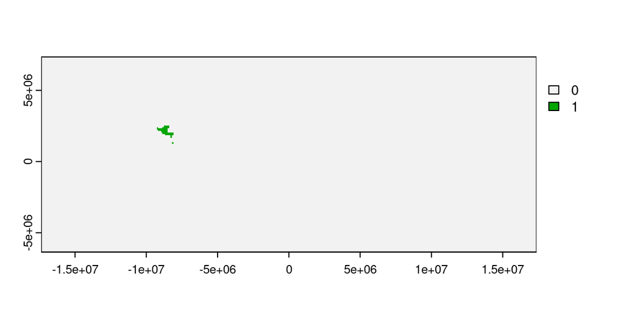

```r
plot(r[[400]])
```

Para ver la riqueza global de mamíferos, podemos hacer la suma de todas las capas, de modo que obtengamos el número de especies por píxel:

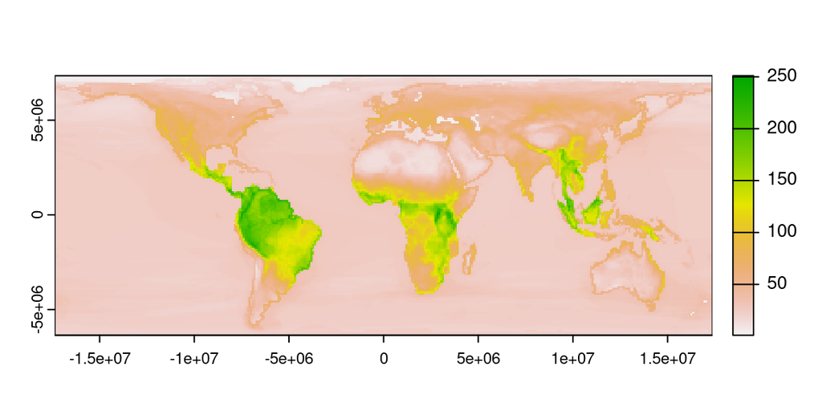

```r
riq <- sum(r)
plot(riq)
```

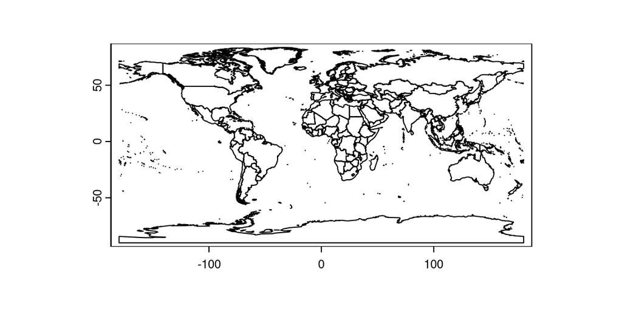

```r
library(maptools)
data("wrld_simpl")
m <- vect(wrld_simpl)
m <- project(m, "EPSG:4326")
plot(m)
```

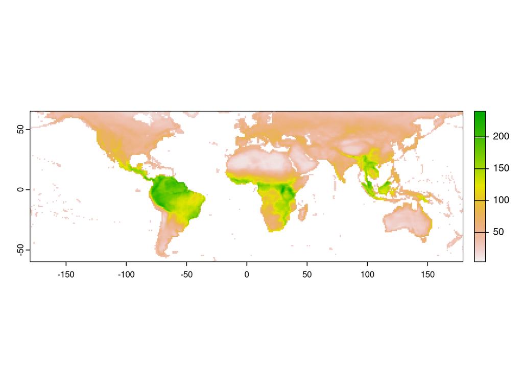

```r
riq <- project(riq, "EPSG:4326")
riq.ter <- mask(riq, m)
plot(riq.ter)
```

Ahora, importaremos las variables bioclimáticas de [Chelsa](https://envicloud.wsl.ch/#/?prefix=chelsa%2Fchelsa_V2%2FGLOBAL%2F) para usar como variables independientes de nuestro modelo de regresión. De Chelsa usaremos las variables bioclimáticas 1, 7 y 12 (temperatura anual promedio, rango anual de temperatura y precipitación total). Estas variables también están en formato `tif` y las podemos importar y proyectar con `terra`:

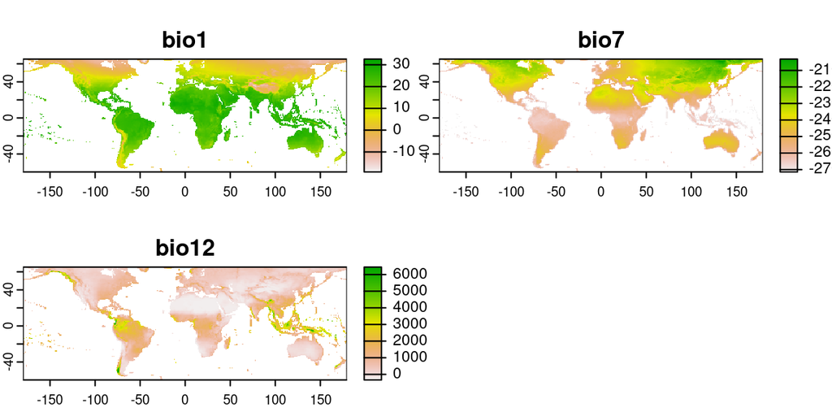

```r
bio <- rast(paste0("../Current/bio",c(1, 7, 12), ".tif"))
bio.res <- resample(bio, riq, method = "lanczos")
bio.res <- mask(bio.res, m)
plot(bio.res)
```

Para hacer un análisis de regresión usando la riqueza como variable dependiente de un conjunto de variables climáticas debemos transformar la capa raster de riqueza a tabla. Antes de ello, necesitamos cambiar el sistema de coordenadas de las capas de riqueza y climáticas a una proyección que preserve mejor las áreas que el sistema de coordenadas geográficas WGS84:

```r
m.88 <- project(m, "EPSG:8857")
riq.88 <- project(riq.ter, "EPSG:8857")
bio.88 <- project(bio.res, "EPSG:8857")

riq.88 <- mask(riq.88, m.88)
bio.88 <- mask(bio.88, m.88)
```

Transformando de raster a tabla:

```r
todos <- c(bio.88, riq.88)
riq.df <- as.data.frame(todos, xy = T)
riq.df$sum <- round(riq.df$sum, 0)
knitr::kable(head(riq.df))
```

|  | x | y | bio1 | bio7 | bio12 | sum |
| --- | --- | --- | --- | --- | --- | --- |
| 69 | -12085265 | 7313734 | -5.073144 | -243.8959 | 289.2390 | 32 |
| 70 | -12010090 | 7313734 | -6.002041 | -241.0531 | 387.0372 | 34 |
| 71 | -11934914 | 7313734 | -6.714367 | -237.8318 | 591.0377 | 34 |
| 72 | -11859738 | 7313734 | -5.802148 | -241.6073 | 608.9218 | 35 |
| 77 | -11483858 | 7313734 | -3.872388 | -243.9792 | 190.6438 | 43 |
| 78 | -11408682 | 7313734 | -4.499725 | -239.2193 | 344.9317 | 44 |

Ahora, podemos hacer un análisis exploratorio, viendo por ejemplo los gráficos de dispersión de la riqueza como función de las variables bioclimáticas:

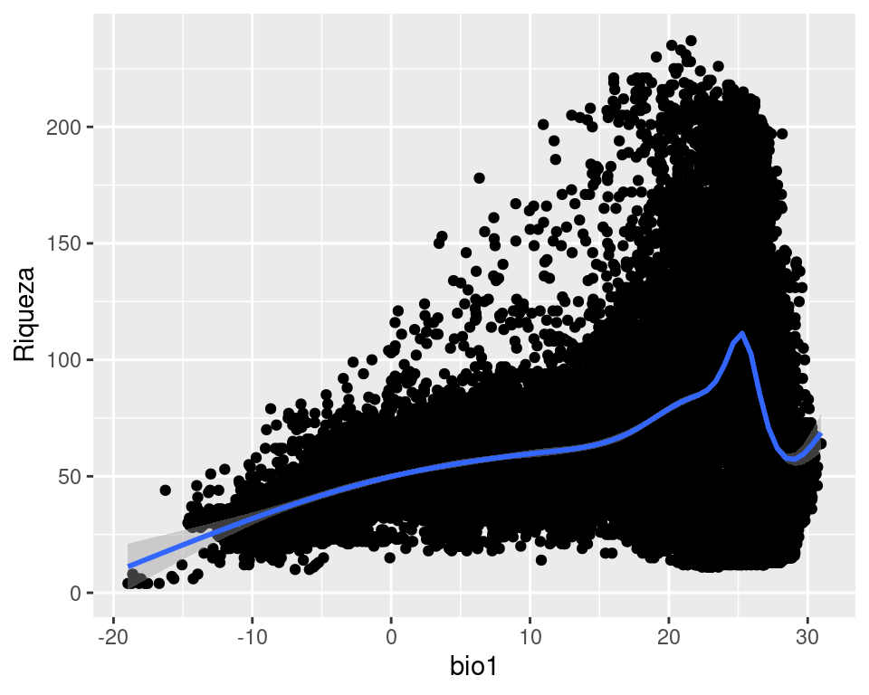

```r
library(ggplot2)

ggplot(riq.df) + geom_point(aes(x = bio1, y = sum)) +
  geom_smooth(aes(x = bio1 , y = sum), method = "gam") +
  labs(y = "Riqueza")
```

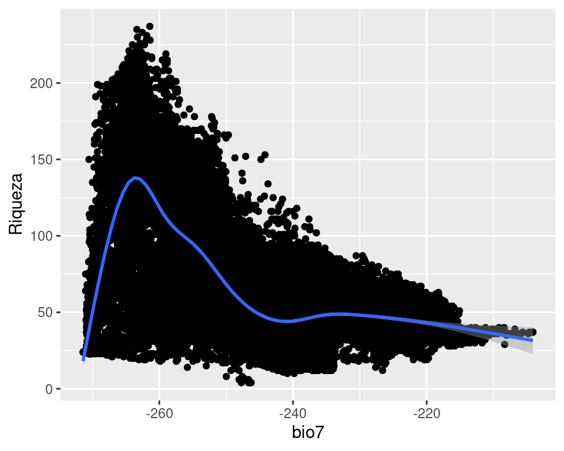

```r
ggplot(riq.df) + geom_point(aes(x = bio7, y = sum)) +
  geom_smooth(aes(x = bio7 , y = sum), method = "gam") +
  labs(y = "Riqueza")
```

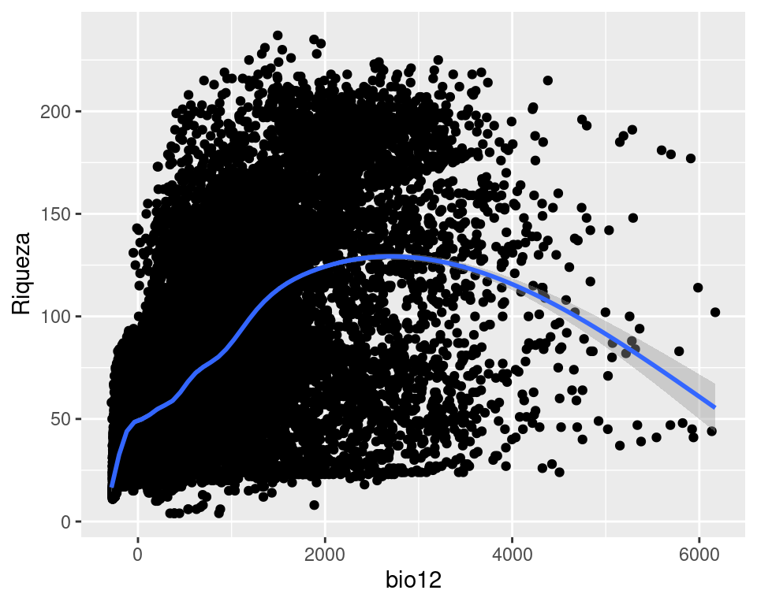

```r
ggplot(riq.df) + geom_point(aes(x = bio12, y = sum)) +
  geom_smooth(aes(x = bio12 , y = sum), method = "gam")+
  labs(y = "Riqueza")
```

Para analizar la riqueza utilizaremos un modelo lineal generalizado Poisson, utilizando los siguientes términos:

1. **Bio1**: lineal
2. **Bio7**: lineal y cuadrático
3. **Bio12**: lineal y cuadrático

```r
m1 <- glm(sum ~ bio1 + bio7 + I(bio7^2) +
            bio12 + I(bio12^2),
          data = riq.df, family = "poisson")
summary(m1)
```

```
##
## Call:
## glm(formula = sum ~ bio1 + bio7 + I(bio7^2) + bio12 + I(bio12^2),
##     family = "poisson", data = riq.df)
##
## Coefficients:
##               Estimate Std. Error z value Pr(>|z|)
## (Intercept) -3.556e+00  2.897e-01  -12.27   <2e-16 ***
## bio1         1.108e-02  1.194e-04   92.77   <2e-16 ***
## bio7        -5.345e-02  2.336e-03  -22.88   <2e-16 ***
## I(bio7^2)   -9.740e-05  4.703e-06  -20.71   <2e-16 ***
## bio12        7.041e-04  2.464e-06  285.71   <2e-16 ***
## I(bio12^2)  -1.383e-07  6.708e-10 -206.24   <2e-16 ***
## ---
## Signif. codes:  0 '***' 0.001 '**' 0.01 '*' 0.05 '.' 0.1 ' ' 1
##
## (Dispersion parameter for poisson family taken to be 1)
##
##     Null deviance: 665170  on 24967  degrees of freedom
## Residual deviance: 326630  on 24962  degrees of freedom
## AIC: 474850
##
## Number of Fisher Scoring iterations: 4
```

De acuerdo con este análisis todas las variables afectan significativamente la riqueza. Ahora veremos cómo representa este modelo los patrones de riqueza:

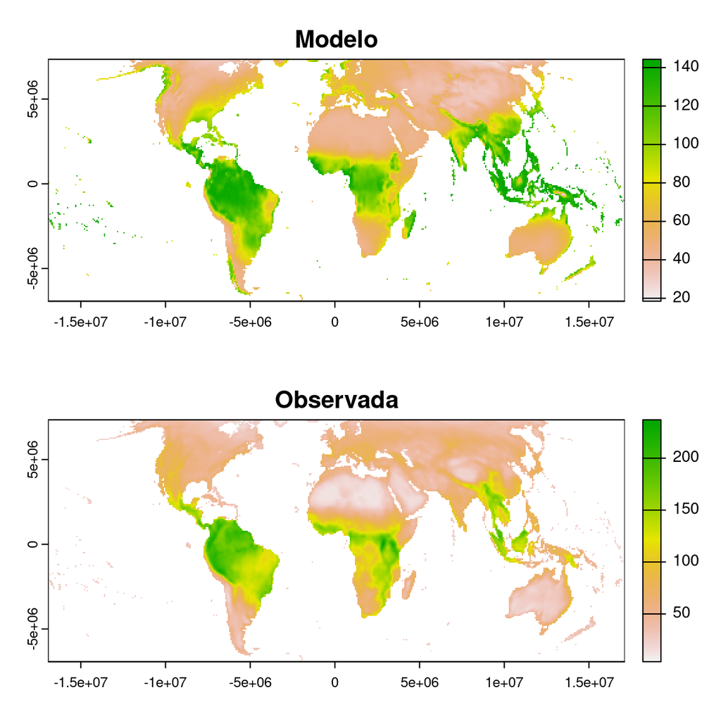

```r
p <- predict(m1)
riq.df$pred.riq <- exp(p)
riq.pred <- rast(riq.df)
par(mfrow = c(2, 1))
plot(riq.pred[["pred.riq"]], main = "Modelo")
plot(riq.pred[["sum"]], main = "Observada")
```

Podemos ver que de manera general, las tres variables sí influencian la riqueza, aunque los mecanismos precisos no los hemos dilucidado aún.

Regresar al índice del curso